# R Notebook

```r
library(tidyverse)
library(lubridate)
library(tsibble)
library(tsibbledata)
library(fable)
library(leaflet)
library(sf)
```

```r
view(nyc_bikes)
?nyc_bikes
```

1. Creating 3 new columns (year_used, month_used and date_used) using the start_time column.

```r
new_nyc_bikes <- nyc_bikes %>%
  mutate(year_used = year(start_time),
         month_used = month((start_time), label = TRUE),
         date_used = date(start_time))
```

2. Summarising the no of bikes by month and making plot.

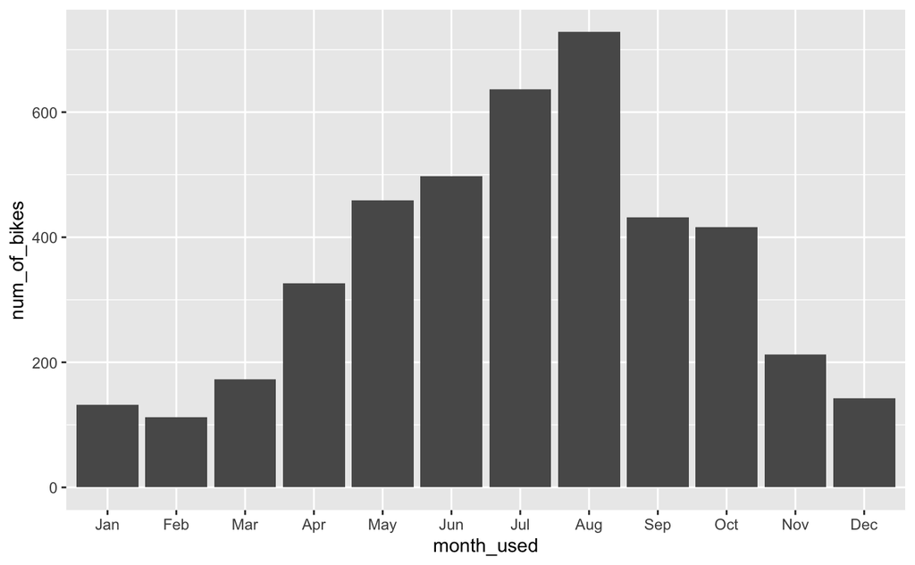

```r
bikes_by_month <- new_nyc_bikes %>%
  index_by(month_used) %>%
  summarise(num_of_bikes = n())

ggplot(bikes_by_month) +
  aes(x = month_used, y = num_of_bikes)+
  geom_col()
```

3. Summarising the no of bikes by date and making plot.

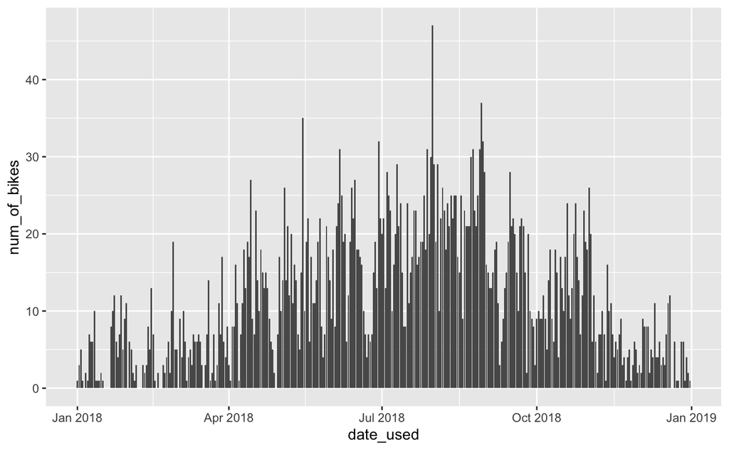

```r
bikes_by_date <- new_nyc_bikes %>%
  index_by(date_used) %>%
  summarise(num_of_bikes = n())

ggplot(bikes_by_date) +
  aes(x = date_used, y = num_of_bikes)+
  geom_col()
```

```
Plot variable not specified, automatically selected `.vars = num_of_bikes`
```

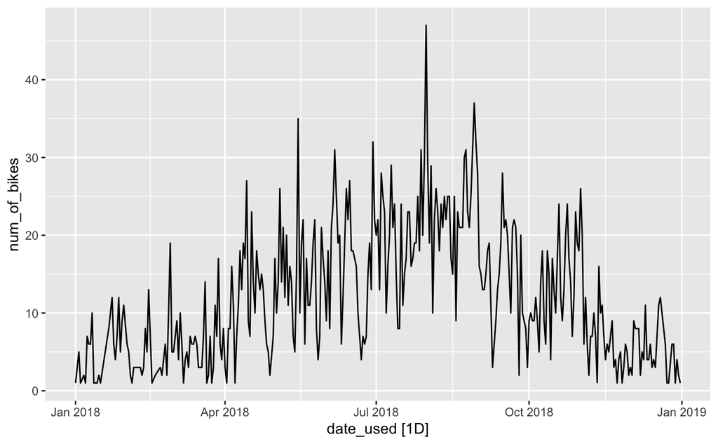

```r
bikes_by_date %>%
  autoplot()
```

```r
new_bikes_by_date <- bikes_by_date %>%
  fill_gaps(num_of_bikes = as.integer(median(num_of_bikes)))


new_bikes_by_date
```

| date_used | num_of_bikes |
| --- | --- |
| 2018-01-01 | 1 |
| 2018-01-02 | 3 |
| 2018-01-03 | 5 |
| 2018-01-04 | 1 |
| 2018-01-05 | 10 |
| 2018-01-06 | 2 |
| 2018-01-07 | 1 |
| 2018-01-08 | 7 |
| 2018-01-09 | 6 |
| 2018-01-10 | 6 |

[output cut: 355 more lines]

```r
model_fit <- new_bikes_by_date %>%
  model(
    snaive_model = SNAIVE(num_of_bikes),
    mean_model = MEAN(num_of_bikes),
    naive_model = NAIVE(num_of_bikes)
  )
```

```r
bike_forecast <- model_fit %>%
  fabletools::forecast(h = 120)
```

```r
bike_forecast %>%
autoplot(new_bikes_by_date, level = NULL)
```

[output not shown]

```r
unique(new_bikes_by_date$date_used)

# 80/ 20 split
# data time index stretches across 361 days
# 361 x 0.8 = 288.8 = 289 (once rounded)

# 289 years training v 72 days left over
```

```r
bikes_training <- new_bikes_by_date %>%
  filter_index("2018-01-01" ~ "2018-10-16")

#fit model on my training data

fit_training <- bikes_training %>%
  model(
    snaive_model = SNAIVE(num_of_bikes),
    mean_model = MEAN(num_of_bikes),
    naive_model = NAIVE(num_of_bikes)
  )

#new forecast based on the training data
forecast_training <- fit_training %>%
fabletools::forecast(h = 120)
```

```
Plot variable not specified, automatically selected `.vars = num_of_bikes`
```

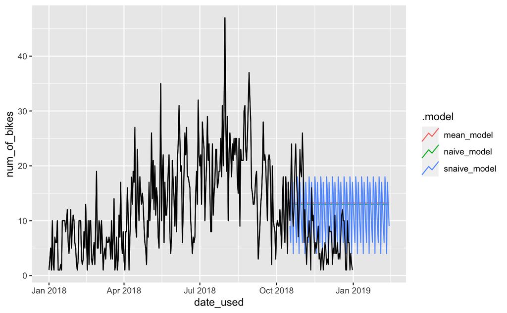

```r
forecast_training %>%
  autoplot(bikes_training, level = NULL) +
  autolayer(filter_index(new_bikes_by_date, "2018-01-01" ~ .), color = "black")
```

```r
accuracy_model <- fabletools::accuracy(forecast_training, new_bikes_by_date)
```

```
The future dataset is incomplete, incomplete out-of-sample data will be treated as missing.
44 observations are missing between 2019-01-01 and 2019-02-13
```

```r
accuracy_model %>%
  arrange(RMSE)
```

| .model | .type | ME | RMSE | MAE | MPE | MAPE | MASE | ACF1 |
| --- | --- | --- | --- | --- | --- | --- | --- | --- |
| naive_model | Test | -4.789474 | 7.751061 | 6.947368 | -223.5692 | 233.7653 | 1.026274 | 0.6563147 |
| mean_model | Test | -5.021308 | 7.896418 | 7.105992 | -229.3395 | 239.1543 | 1.049706 | 0.6563147 |
| snaive_model | Test | -3.486842 | 8.606148 | 6.907895 | -203.3864 | 225.0217 | 1.020443 | 0.2992849 |

None of the models could be described as good fits for forecasting the data.

The snaive_model, based on the forecast_training plot looks to be the best fit out of the three but according to the results from the accuracy test, the naive model is the most accurate.

Neither the mean model or the naive model look like good fits on the forecast_training plot as they do not resemble the data’s peaks and throughs.

A testing a different model would probably be the best the solution in this case as there should already be enough data to be able to forecast.

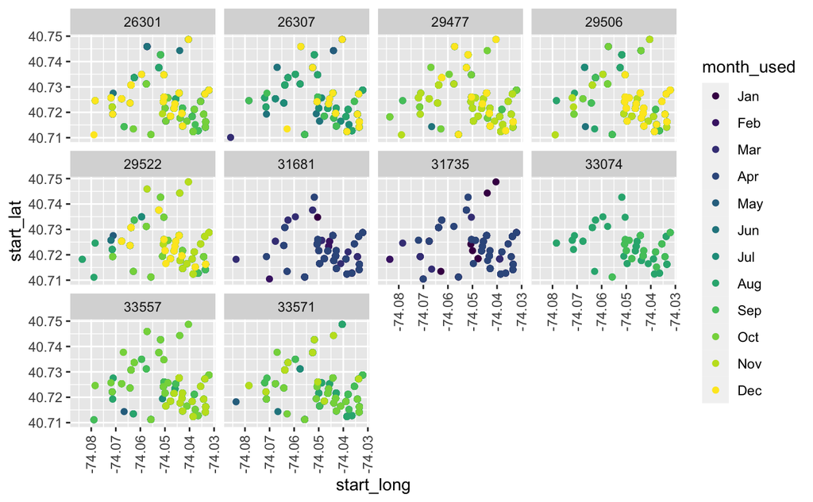

```r
ggplot(new_nyc_bikes) +
  aes(x = start_long, y = start_lat, colour = month_used) +
  geom_point() +
  facet_wrap(~ bike_id) +
  theme(axis.text.x = element_text(angle = 90, vjust = 0.5, hjust=1))
```

```r
ggplot(new_nyc_bikes) +
  aes(x = end_long, y = end_lat, colour = month_used) +
  geom_point() +
  facet_wrap(~ bike_id) +
  theme(axis.text.x = element_text(angle = 90, vjust = 0.5, hjust=1))
```

[output not shown]

These plots tell you that the bikes were not used every month and the data is effected by seasons.

```r
nyc_bikes_map <- leaflet(nyc_bikes) %>%
 addTiles() %>%
  addMarkers(lng = ~start_long, lat = ~start_lat, clusterOptions = markerClusterOptions(), popup = nyc_bikes$bike_id)

nyc_bikes_map
```

[interactive chart not shown]